# Time Series Classification

# Intro

I adapted the problem from the following link http://kdd.ics.uci.edu/databases/synthetic_control/synthetic_control.data.html. The goal is to classify the time series into 1 of 6 types of time series.

This dataset contains 600 examples of control charts synthetically generated by the process in Alcock and Manolopoulos (1999). There are six different classes of control charts:

1. Normal
2. Cyclic
3. Increasing trend
4. Decreasing trend
5. Upward shift
6. Downward shift

The following image shows ten examples from each class:

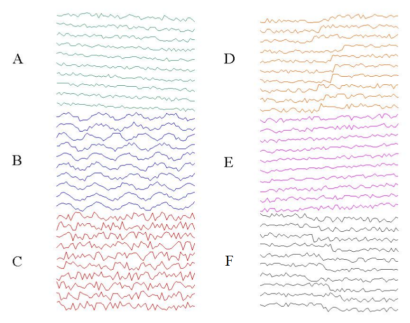

# Load Required Packages in R `NNS (>= 3.9.1)`

```r
require(devtools); install_github('OVVO-Financial/NNS', ref = "NNS-Beta-Version")
require(NNS)
require(plyr)
require(data.table)
```

# Download Data

Scan from URL and convert into matrix with each observation as a column.

```r
tsdata <- scan(url("http://kdd.ics.uci.edu/databases/synthetic_control/synthetic_control.data"))
tsdata <- matrix(tsdata, ncol=60, byrow = TRUE)
dim(tsdata)
```

```
## [1] 600  60
```

# Augment `tsdata` matrix with labels

The following were put into columns of the matrix `tsdata`:

- There are 60 observations per time series, as features or columns
- We have the classification ID, per time series class it belongs to. The classes are organized as follows:

  ```
    1-100   Normal
    101-200 Cyclic
    201-300 Increasing trend
    301-400 Decreasing trend
    401-500 Upward shift
    501-600 Downward shift
  ```

This leaves us with a matrix of 600 rows and 61 columns.

```r
series = cbind(tsdata ,class.id = rep(1:6, each = 100))
dim(series)
```

```
## [1] 600  61
```

# Create `train` and `test` sets

There are 600 time series, we will randomly remove 20% of the time series for an out of sample experiment.

```r
set.seed(123)
test.index = sample(1:600, 120, replace = FALSE)
test.index
```

```
##   [1] 173 473 245 528 561  28 314 530 327 270 565 268 399 337  61 527 144
##  [18]  25 191 555 516 402 371 574 378 408 313 341 166  85 549 514 393 452
##  [35]  14 591 428 122 179 130  80 232 231 206 571  78 596 258 147 599  26
##  [52] 243 438  67 307 113  70 410 486 203 360  52 207 148 437 240 433 434
##  [69] 423 234 400 333 375   1 251 116 200 321 184  58 127 347 217 575  54
##  [86] 224 507 459 454  90 547 529 175 509 163  95 395  48 235 257 300 167
## [103] 244 475 535 441 567 301 541  73 513 537  30 462 351 544 266 461 283
## [120] 195
```

Checking our dimensions to ensure 120 time series have been removed.

```r
training.ts.set = series[-test.index, ]
dim(training.ts.set)
```

```
## [1] 480  61
```

```r
test.ts.set = series[test.index, ]
dim(test.ts.set)
```

```
## [1] 120  61
```

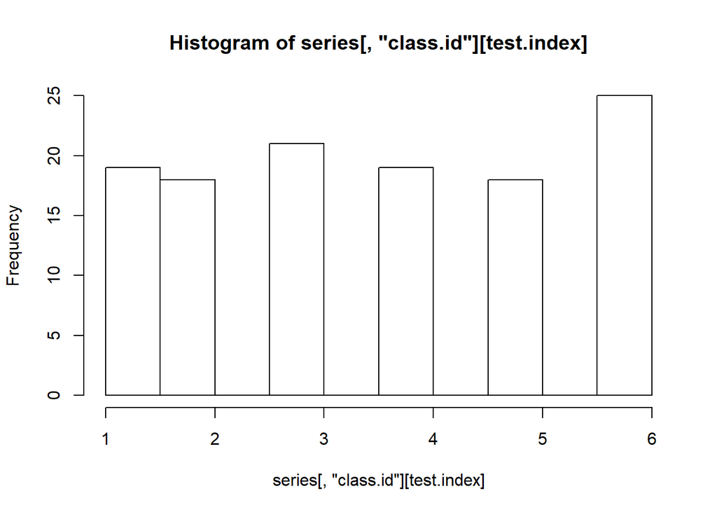

```r
# Distribution of test set classifications
hist(series[ , "class.id"][test.index])
```

# Use `NNS.reg` to find the most similar

The following settings in `NNS.reg(..., order = "max", n.best = 1, ...)` are very similar to a KNN = 1 (with the `NNS` general case exhibiting significant weighting differences and less sensitivity to the curse of dimensionality). We set up the following independent variables for training `IVs.train`, the dependent variable `DV` which is the `class.id` from our earlier training set `training.ts.set`, and our independent variables for testing `IVs.test`.

```r
IVs.train = training.ts.set[ , colnames(training.ts.set) != "class.id"]
DV = training.ts.set[ , "class.id"]
IVs.test = test.ts.set[ , colnames(test.ts.set) != "class.id"]
```

Using these variables in our `NNS.reg` we store our `Point.est` as `predictions`

```r
predictions = NNS.reg(IVs.train, DV, point.est = IVs.test, order = "max", n.best = 1, plot = FALSE, residual.plot = FALSE)$Point.est
```

Finally, a check of our accuracy yields:

```r
mean(round(predictions) == test.ts.set[ , "class.id"])
```

```
## [1] 0.9833333
```

# More seeds

Let’s try 100 different seeds and visualize the results.

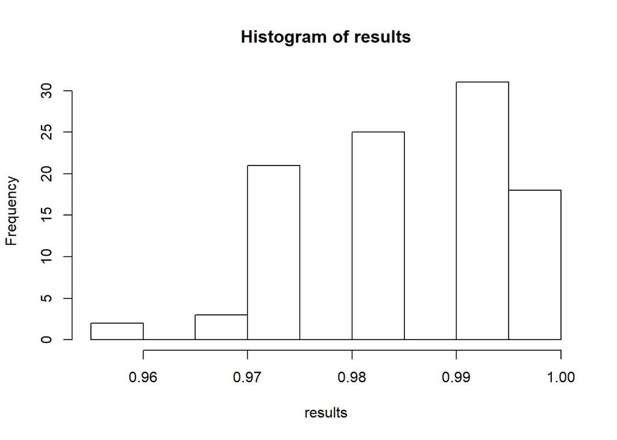

```r
results=numeric()

for(i in 1:100){
set.seed(123+i)
test.index = sample(1:600, 120, replace = FALSE)

training.ts.set = series[-test.index, ]
test.ts.set = series[test.index, ]

IVs.train = training.ts.set[,colnames(training.ts.set) != "class.id"]
DV = training.ts.set[, "class.id"]
IVs.test = test.ts.set[,colnames(test.ts.set) != "class.id"]

predictions = NNS.reg(IVs.train, DV, point.est = IVs.test, order = "max", n.best = 1, plot = FALSE, residual.plot = FALSE)$Point.est

results[i] = mean(round(predictions) == test.ts.set[ , "class.id"])
}

hist(results)
```

```r
mean(results); sd(results)
```

```
## [1] 0.9861667
```

```
## [1] 0.00999579
```

# Comments

By reducing the `order` parameter in the `NNS.reg` function, we can encode the time series with its regression points, which are clusters, thus permitting larger time-series analysis. This is an active area of development. Also, partial time-series matching is another area of active development.

If you found this presentation interesting or useful, please feel free to reach out via e-mail: ovvo.financial.systems@gmail.com

Thanks for your interest!